# EDA tv play

# 1 はじめに

## 1.1 setup

## 1.2 tv_play データ

TV再生ログが入っている．カラムは

- action_datetime：行動日時（0000始まり2359終わり）
- action_day_week：行動曜日（業界日付による曜日：0500始まり2859終わり）
- house_num：世帯id
- tv_num：テレビid
- station_code：放送局id
- timeshift_datetime：タイムシフト放送日（0000始まり2359終わり）
- timeshift_date_week：タイムシフト放送曜日（業界日付による曜日：0500始まり2859終わり）
- action_date：行動日（業界日付：0500始まり2859終わり）

の8列．レコード数は44170240．

以下推測

- 「テレビ再生ログ」であるが，おそらく「テレビを点けた」or「チャンネルを変えた」ときにログが記録されたおの
- 確信が持てないが多分そう
- なぜなら，「いつから」見たかのtimestampは有るが「いつまで」が無い
- ただし，station_codeカラムがあるため，「チャンネルを変えた」ログもあると思われる
- たとえば，連続的に次々とチャンネルを変えたときはどうなるのだろうか

とりあえず，上から1000行ぐらいを見て雰囲気を掴む

|  | action_datetime | action_day_week | house_num | tv_num | station_code | timeshift_datetime | timeshift_date_week | action_date | timeshift_date |
| --- | --- | --- | --- | --- | --- | --- | --- | --- | --- |
| 1 | 2017-04-11T01:26:00Z | 2 | 00015 | 2 | 3 | 2017-04-10T13:26:00Z | 1 | 2017-04-11 | 2017-04-10 |
| 2 | 2017-04-10T20:39:00Z | 2 | 00030 | 1 | 4 | 2017-04-10T03:06:00Z | 1 | 2017-04-11 | 2017-04-10 |
| 3 | 2017-04-11T19:23:00Z | 2 | 00047 | 1 | 4 | 2017-04-11T14:44:00Z | 2 | 2017-04-11 | 2017-04-11 |
| 4 | 2017-04-11T11:07:00Z | 2 | 00084 | 1 | 6 | 2017-04-10T14:09:00Z | 1 | 2017-04-11 | 2017-04-10 |
| 5 | 2017-04-11T12:16:00Z | 2 | 00123 | 1 | 6 | 2017-04-11T03:57:00Z | 2 | 2017-04-11 | 2017-04-11 |
| 6 | 2017-04-11T02:44:00Z | 2 | 00148 | 1 | 5 | 2017-04-10T23:42:00Z | 2 | 2017-04-11 | 2017-04-11 |
| 7 | 2017-04-11T04:21:00Z | 2 | 00156 | 1 | 1 | 2017-04-10T11:14:00Z | 1 | 2017-04-11 | 2017-04-10 |
| 8 | 2017-04-11T08:01:00Z | 2 | 00156 | 1 | 5 | 2017-04-08T15:53:00Z | 6 | 2017-04-11 | 2017-04-08 |
| 9 | 2017-04-11T11:59:00Z | 2 | 00164 | 1 | 3 | 2017-04-09T09:18:00Z | 7 | 2017-04-11 | 2017-04-09 |
| 10 | 2017-04-11T13:06:00Z | 2 | 00176 | 1 | 5 | 2017-04-10T11:01:00Z | 1 | 2017-04-11 | 2017-04-10 |

[output cut: 990 more lines]

# 2 カラムごと

まずはカラムごとにデータを眺める

## 2.1 action_datetime

タイムシフト視聴したときのtimestamp  
簡単な基本統計量は以下

- min : 2017-04-03 05:00:00
- med : 2017-10-07 18:45:00
- max : 2018-04-02 04:59:00

まず，時間帯でのタイムシフト視聴の分布を見る

- 2峰性の分布
- 午前4時がもっとも少なく，業界日付が5時スタート4時59分終わりなのも頷ける

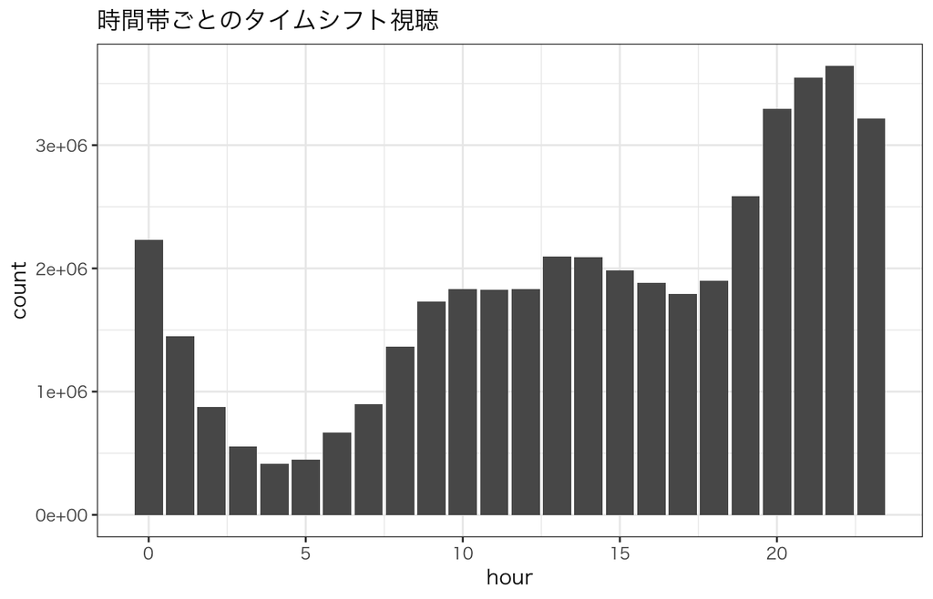

ここからは, **action_datetimeについてはすべて業界日付ベースで見ていく**

### 2.1.1 daily(日付)

- 青線はLOWESS回帰
- データが1年分しかないので年の周期みたいなものは本当にあるかわからない
- 年末年始にかなり高い（みんなテレビ見る）
- 週の周期が大きそう

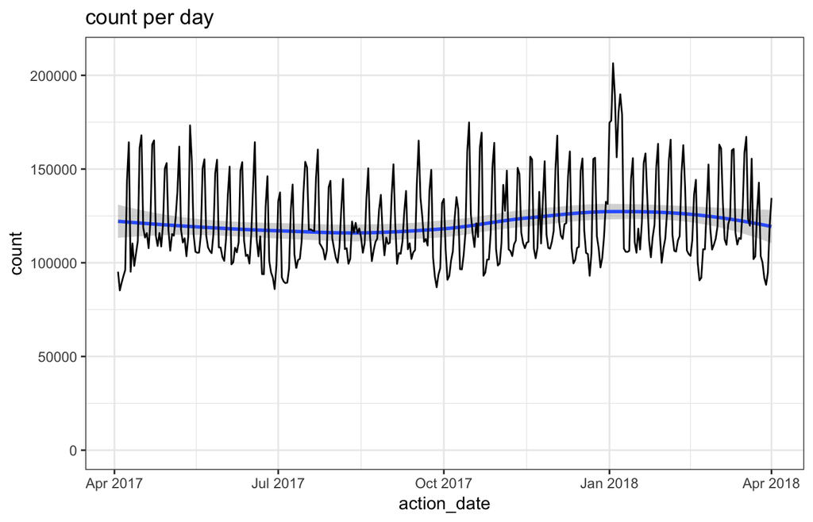

### 2.1.2 weekly

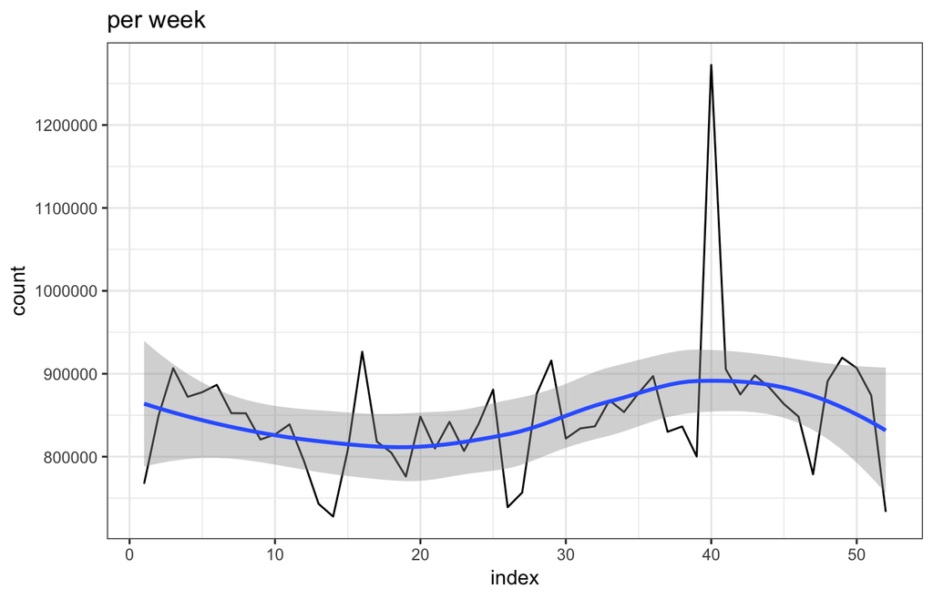

### 2.1.3 monthly

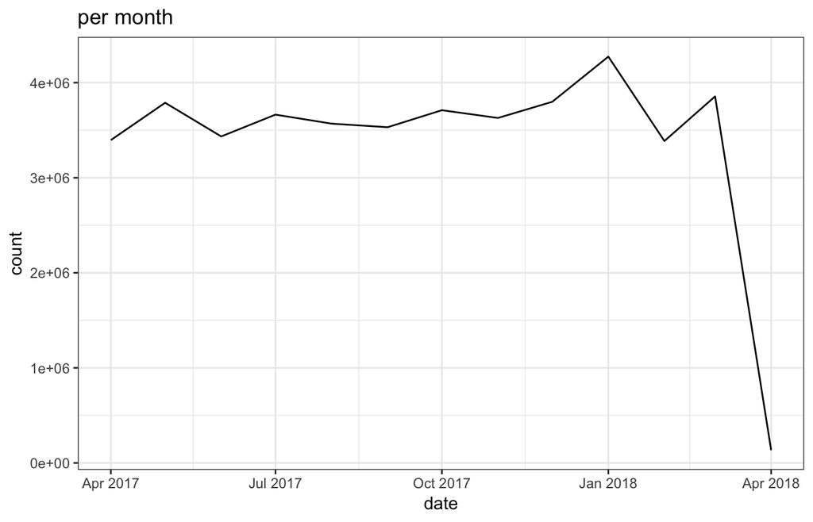

### 2.1.4 day of week

- 日曜日のレコードが最も多い．次点が土曜
- 他はだいたい同じ
- 金曜日が多いと思っていたので意外
- **縦軸端折ってるので注意**

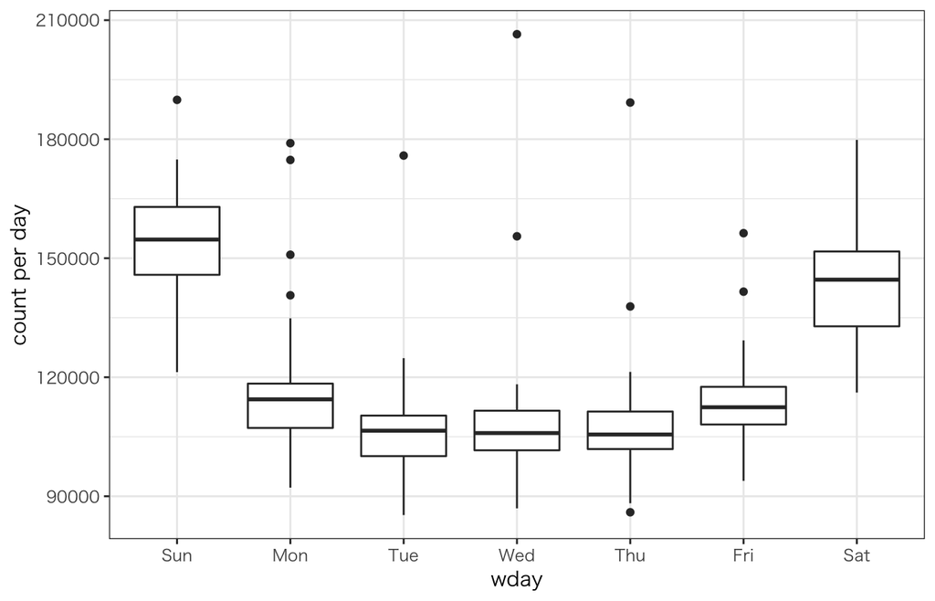

## 2.2 timeshift_datetime

タイムシフトで見た番組の**放送**timestamp

- min : 2017-03-27 05:30:00
- median : 2017-10-05 21:59:00
- max : 2018-04-02 02:37:00

こちらもまずは時間帯別のログ数を見てみる

- こちらも4, 5時で最も低い．
- やはり業界日付で扱っていくのがいいか
- action_timestampの分布とかなり異なる
- 各山の尖度が大きいイメージ
- この辺の比較ができたらおもしろいかも
- **タイムシフトで見る対象番組は21時放送あたりに集中している**
- 一方タイムシフトでactionする時間はもっと滑らかになる

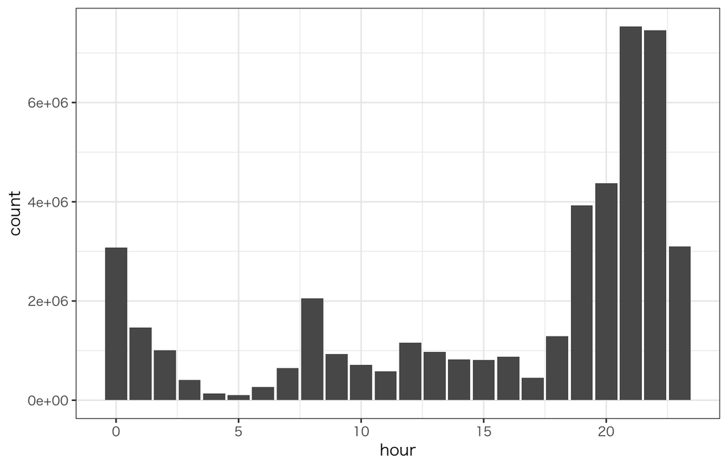

timeshift_datetimeも，**業界日付**で見ていく

### 2.2.1 daily(日付)

- 週の周期がかなり大きそう

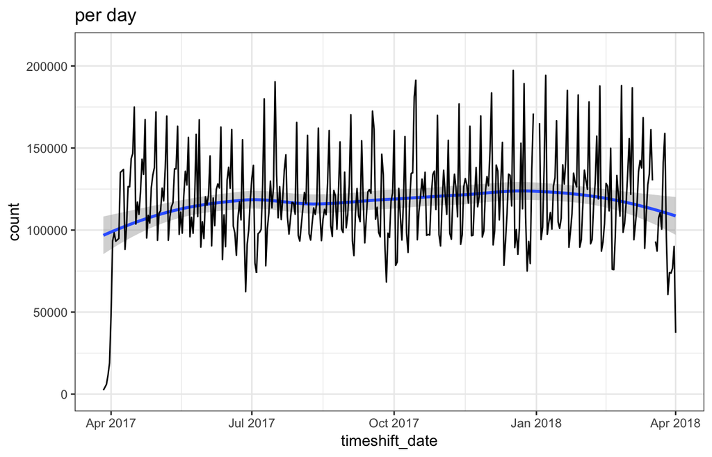

### 2.2.2 weekly

- 年末年始でかなり高い

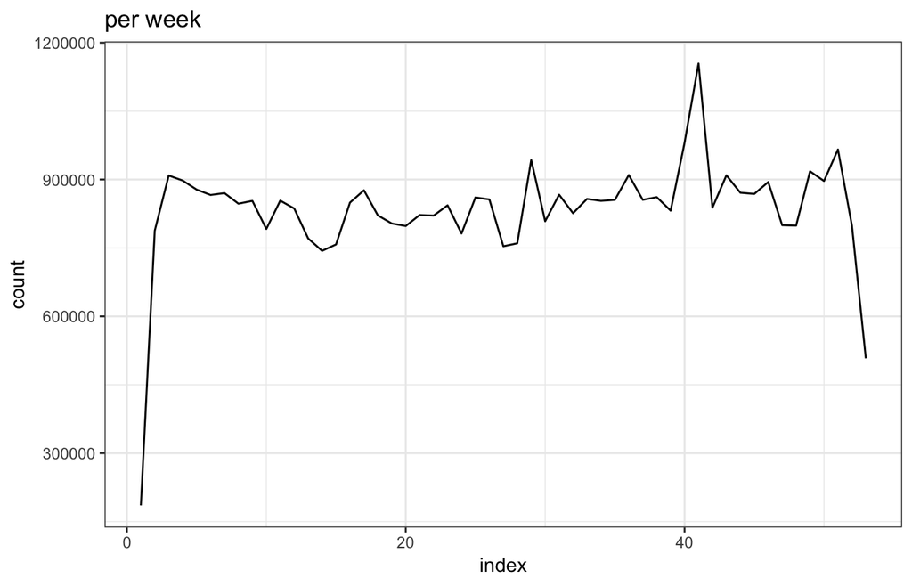

### 2.2.3 monthly

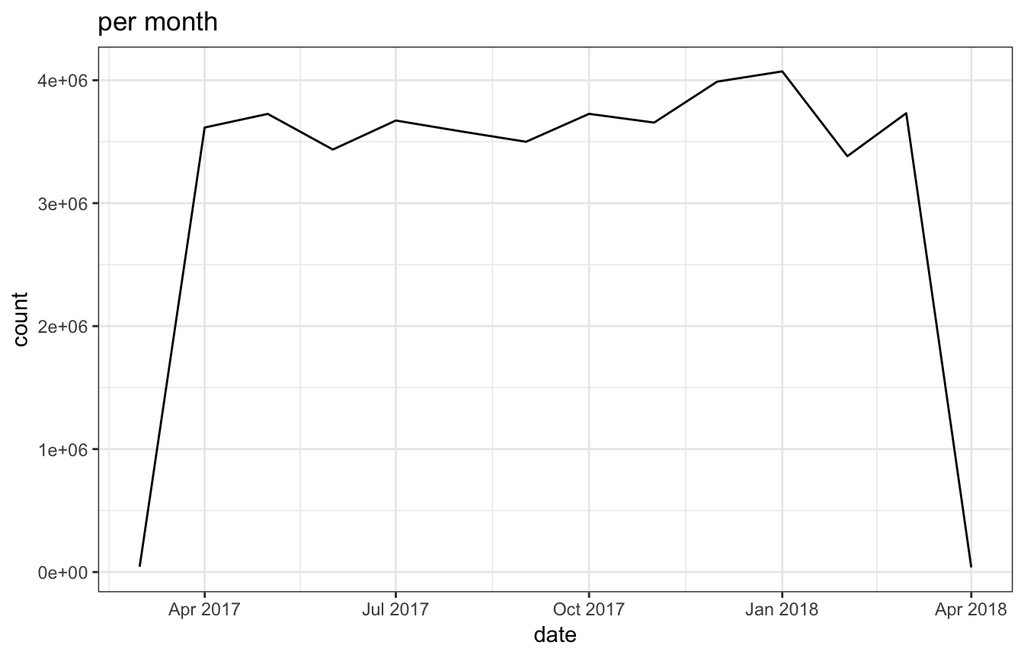

### 2.2.4 day of week

- 対象番組の放送曜日は日曜に集中している
- タイムシフトでactionする曜日とかなり異なるので面白い
- １週間録画した番組を日曜日に見る感じか

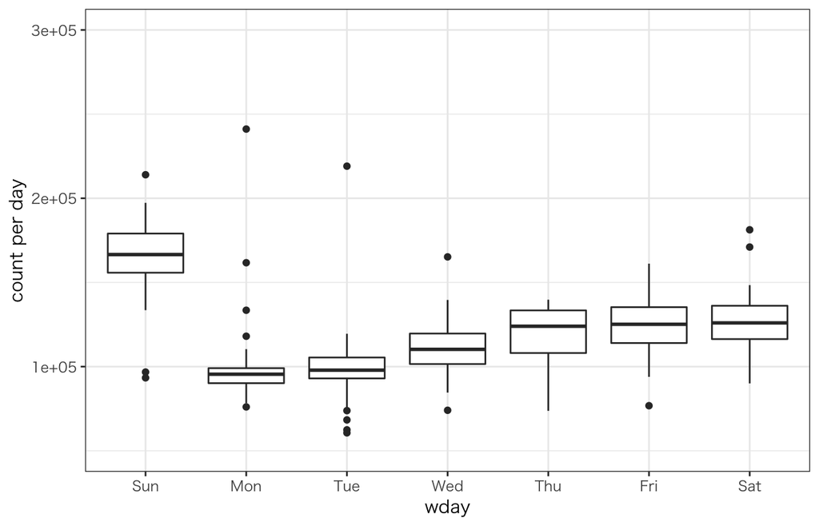

## 2.3 house_num

- ユニークなhouse_numは5933

house_numごとのレコード数を集計

- median < mean が顕著
- 220329回もテレビ付けるやつがいるらしい

| min | q10 | median | mean | q90 | max | sd |
| --- | --- | --- | --- | --- | --- | --- |
| 1 | 83 | 2821 | 7445 | 19534 | 220329 | 12788 |

続いて，ヒストグラムをプロットしてみる

- 予想通り，かなり右に裾がひろい

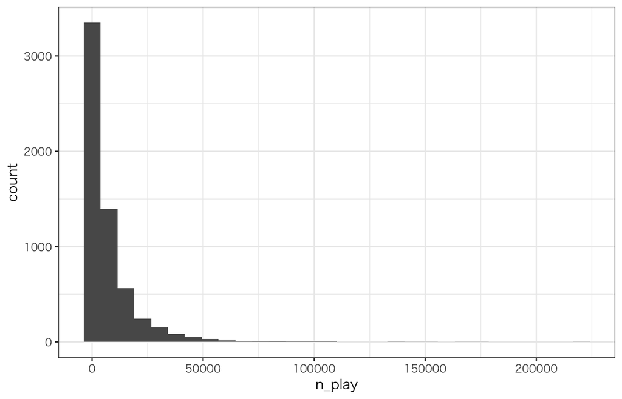

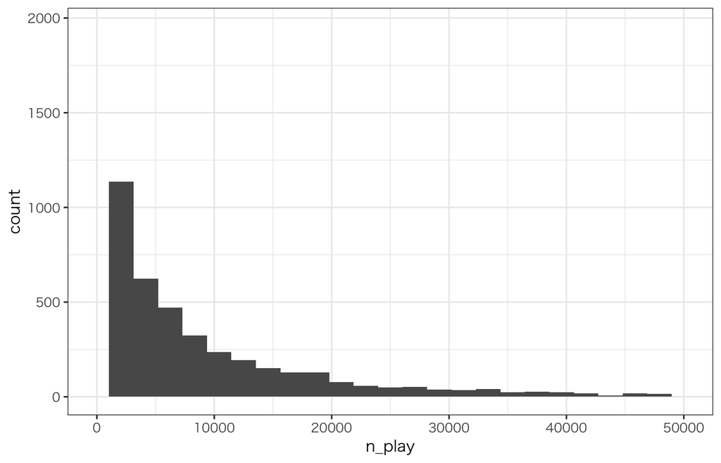

## 2.4 tv_num

- 当然tv_num = 1がもっとも多い．

tv_numごとのログ数

| tv_num | count | rate |
| --- | --- | --- |
| 1 | 41134460 | 0.9312709 |
| 2 | 2685353 | 0.0607955 |
| 3 | 350427 | 0.0079336 |

house_numごとにmax(tv_num)を算出して集計

max(tv_num)ごとのログ数

| max_tv_num | count | rate |
| --- | --- | --- |
| 1 | 37383402 | 0.8463482 |
| 2 | 5873436 | 0.1329727 |
| 3 | 913402 | 0.0206791 |

## 2.5 station_code

- 日テレ, フジ, テレ朝の3強か

station_code ごとのログ数

| station_code | count | station_jp | station_ab |
| --- | --- | --- | --- |
| 7 | 1550419 | ＮＨＫＥテレ | NHK2 |
| 6 | 3860378 | ＮＨＫ総合 | NHK1 |
| 5 | 6394707 | テレビ東京 | TX |
| 2 | 6855340 | ＴＢＳ | TBS |
| 3 | 8117345 | フジテレビ | FUJI |
| 4 | 8544121 | テレビ朝日 | EX |
| 1 | 8847930 | 日本テレビ | NTV |

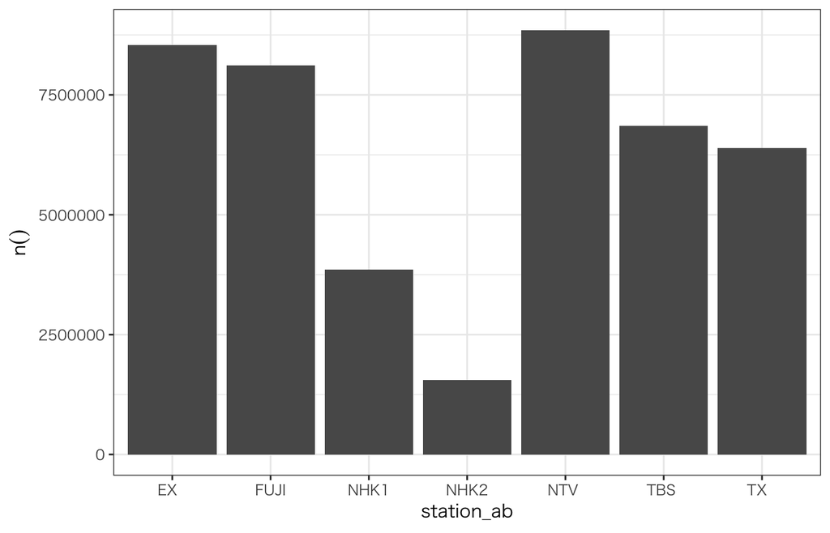

# 3 2変量

## 3.1 action_hour vs timeshift_hour

何時の番組を何時にタイムシフトで見ているのかの可視化

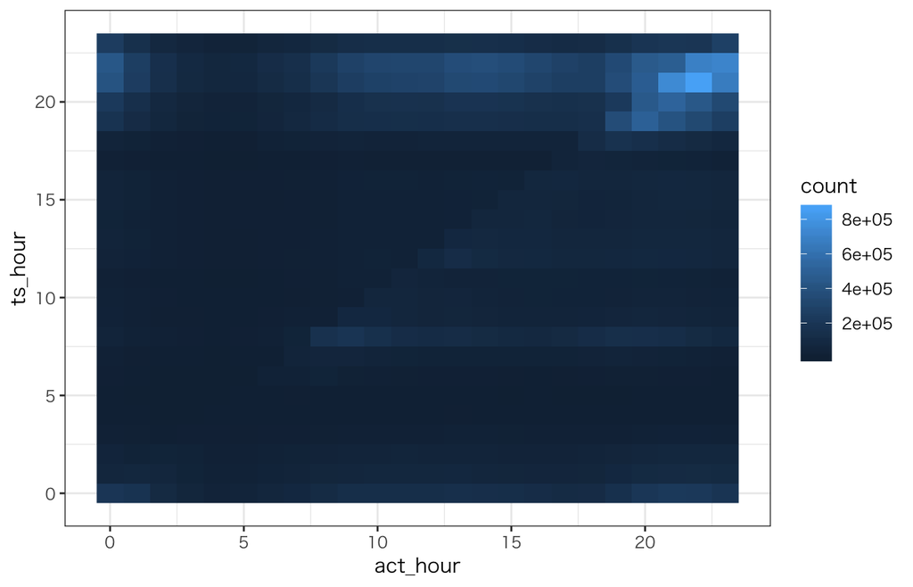

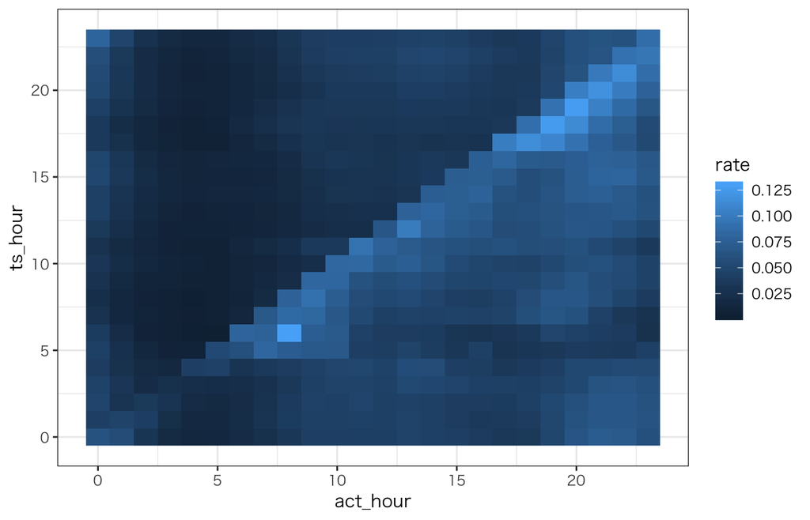

## 3.2 action_dow vs timeshift_dow

何曜の番組を何曜に見ているのかの作図

- 録画した次の日に見る傾向がある

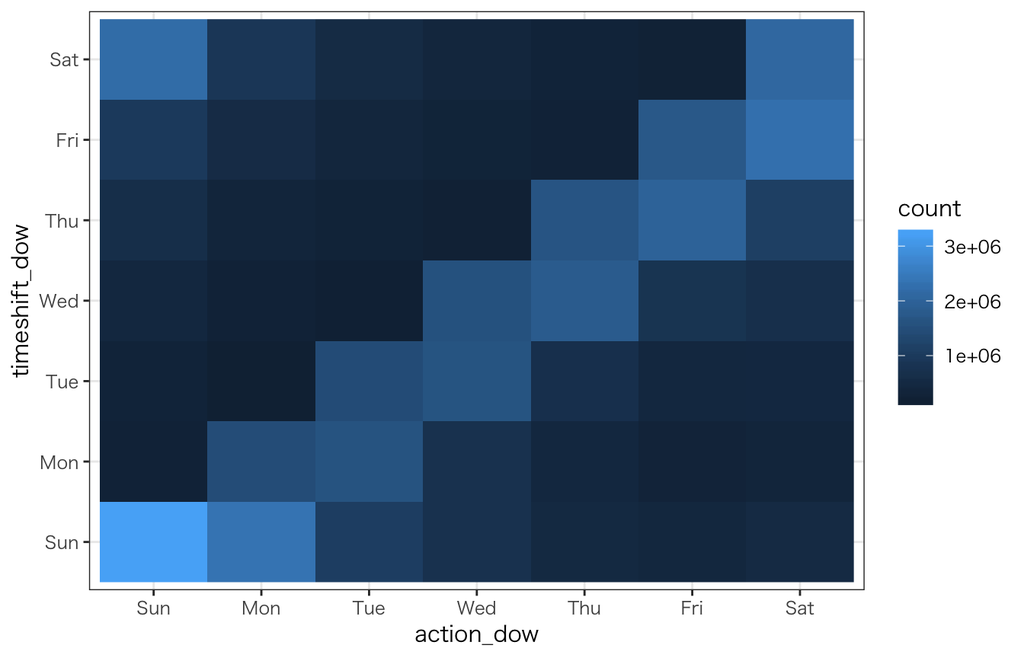

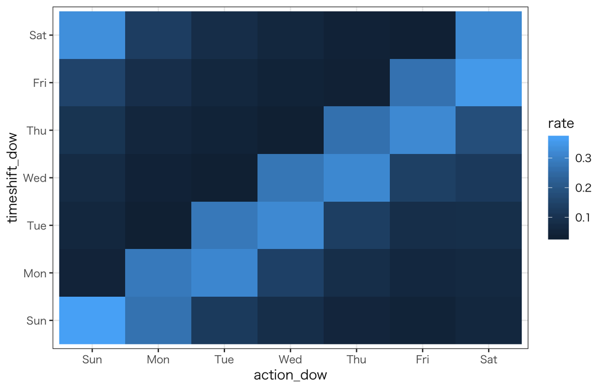

## 3.3 hourly distribution of action_date by DoW

曜日ごとに，何時にactionしてるかの可視化

- ほとんど変わらない
- 強いて言うなら土日 vs 平日

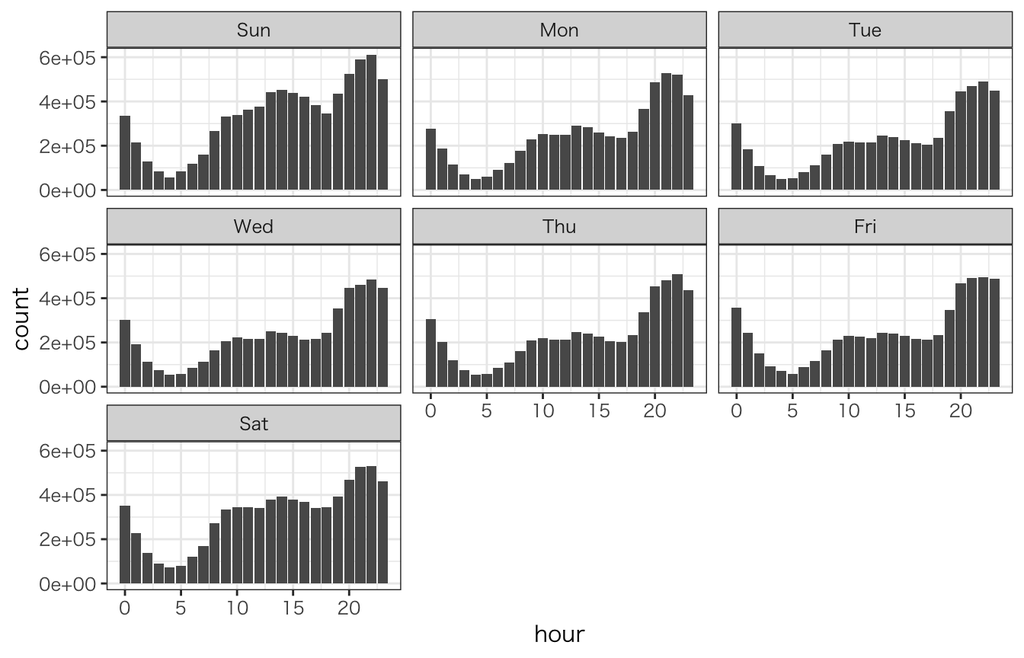

## 3.4 hourly distribution of timeshift_date by DoW

曜日ごとに，何時に放送された番組を見ているかの可視化

- 割と変わる
- なんで？？
- 土曜日放送の番組は夜にまんべんなく見られる

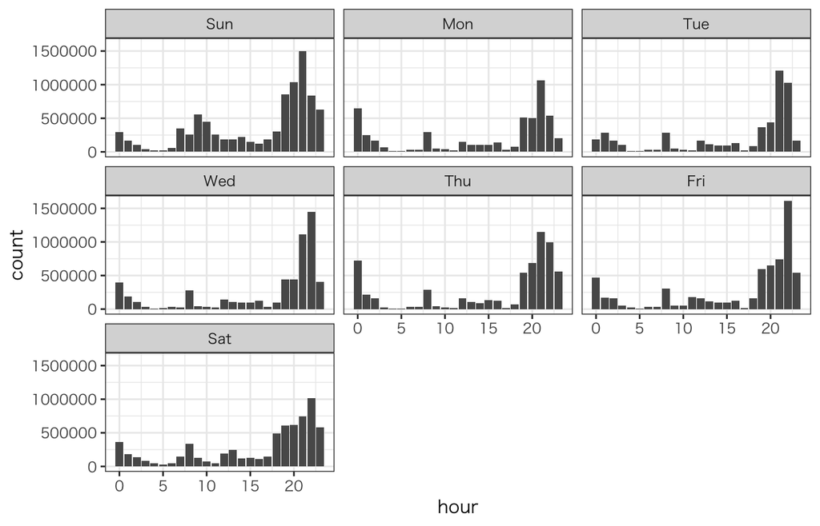

# 4 少しだけやりたかったこと

## 4.1 distribution of action_hour by house_num

世帯ごとに，いつタイムシフト視聴しているか

- 世帯ごとに全然分布が違う
- なんかできないか
- 企業としては，できるだけ「顧客と相性の良いCMを見せたい」
- サーキュラー使えないかな
- マッチング？
- KL距離の最小化？

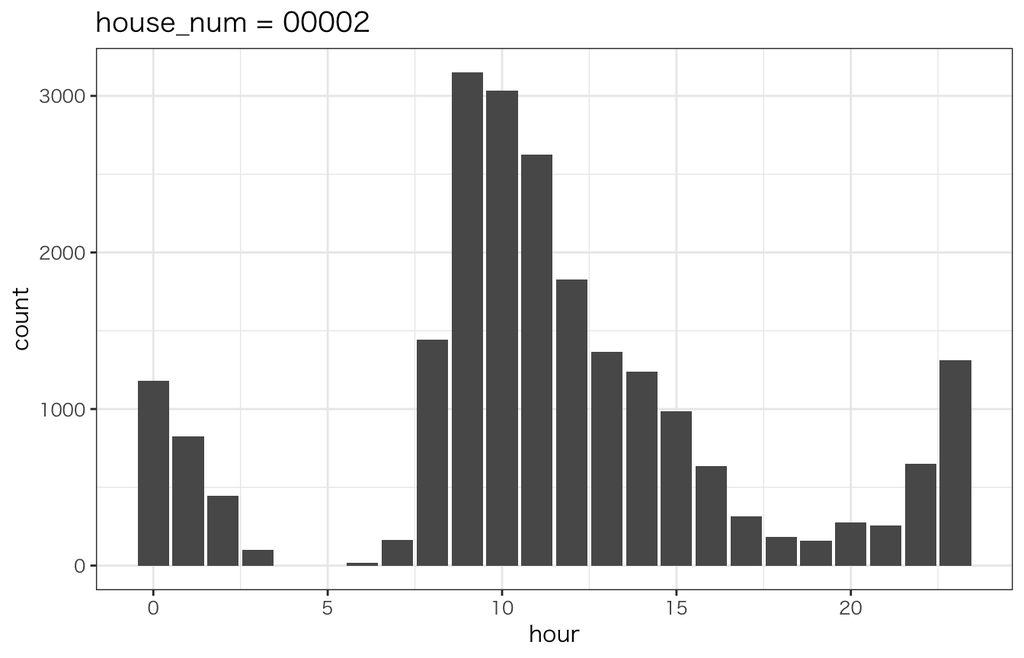

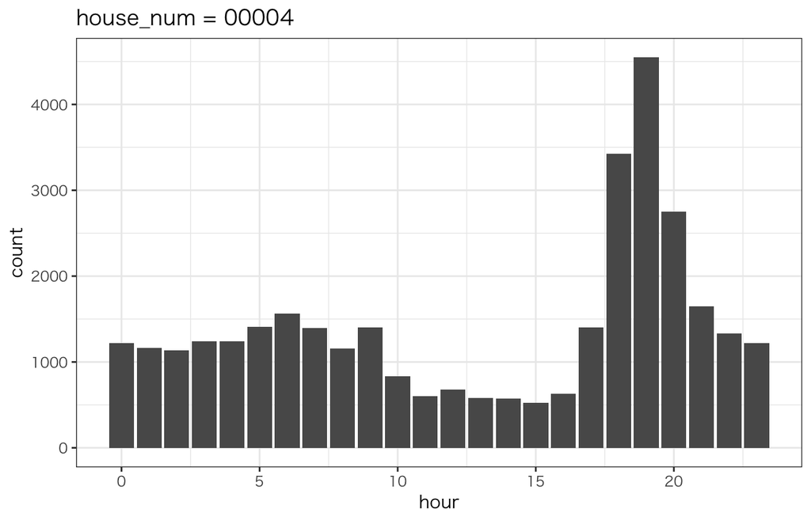

## 4.2 distribution of timeshift_hour by house_num

世帯ごとに，いつ何時放送の番組を見ているか  
timeshift_hourでも同じことをやってみる

- 全然違うけどやはりピークがある
- 録画に番組の嗜好が強く出る？
- リアルタイムで見る方はだらだら見てるということ？

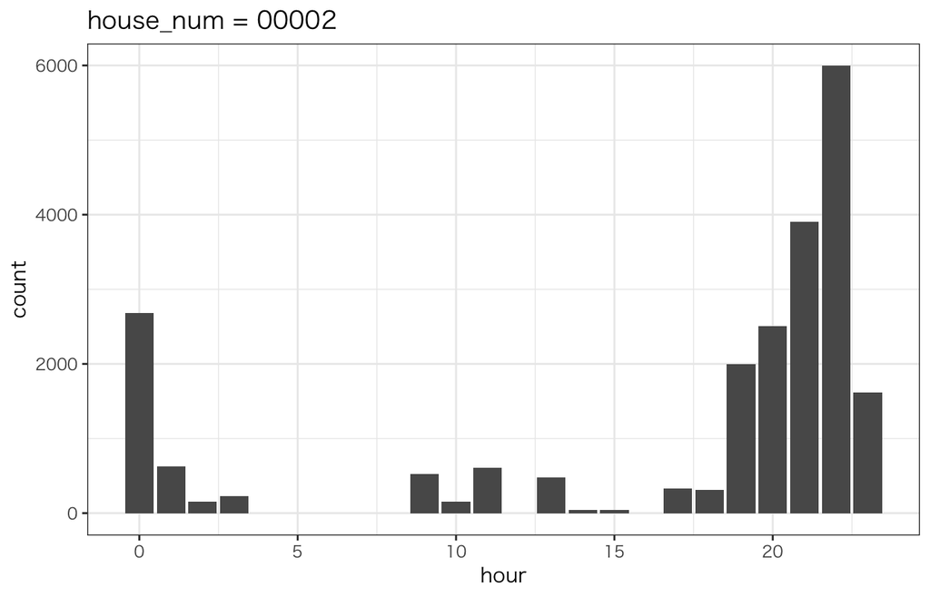

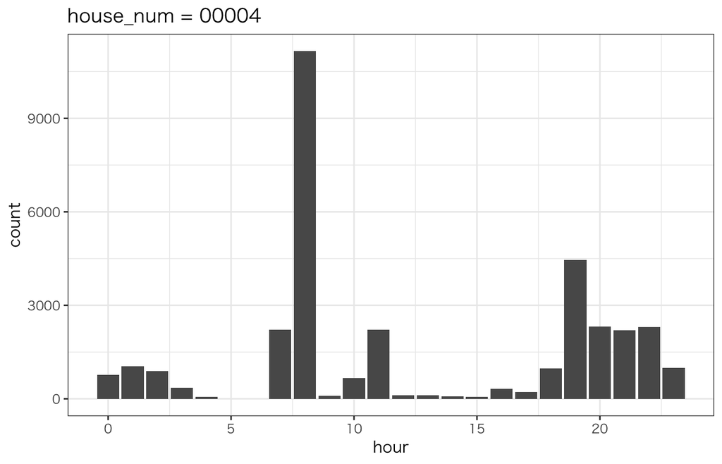

# 5 今後の展望

- 番組データと合わせながら何かできないか
  - 分類や局など
  - CMとも合わせられる
  - タイムシフトはCMを飛ばす？？